# Winter/Summer - stats testing

# evidence of meeting PDA outcome 2.6.

# Statistical analyses to identify patterns, trends and relationships in the dataset

# evidence of meeting PDA outcome 2.7.

# Interpreting the results of statistical analysis

```r
library(tidyverse)
library(infer)
library(lubridate)
```

define functions

```r
source(here::here("r_scripts_and_notebooks/fun_smoother.R"))
source(here::here("r_scripts_and_notebooks/fun_stats_test.R"))
```

some not so successful attempts at setting up code for use in dashboard making it so it will run with any dataset and not just this one note that data must just be one timeries. date must be date format either weekly or monthly.

load data here

```r
admissions_spec <- read_csv(here::here("clean_data/weekly_admissions_spec_clean.csv"))
delayed_discharge <- read_csv(here::here("clean_data/delayed_discharge_clean.csv"))
```

```r
#define filters
input <- list(dataset = "delayed_discharge", age_group = "All (18plus)", healthboard = "All Scotland")
```

```r
#define parametrs to plot
selection <- 1
lookup_dataset <- list("delayed_discharge","admissions_spec")
lookup_param <- list("number_of_delayed_bed_days","number_admissions")
lookup_date <- list("wdate","mdate")
lookup_indicator <- list("weekly","monthly")
```

```r
# how to evaluate when passing in variable names?
eval(str2expression(str_c("seldata <- ",input$datase)))
eval(str2expression(str_c("choice1=unique(seldata$",lookup_param[1],")")))
```

## start here

this is an example where we need to remove long term trend if we are to reveal any seasonal differences

```r
seldata <- delayed_discharge %>%
  filter(hb_name == "All Scotland") %>%
  filter(age_group == "All (18plus)") %>%
  #using this filter - dont expect a significant result
  filter(reason_for_delay == "All Delay Reasons") %>%
  # using this filter expect a significant result
  #filter(reason_for_delay == "Code 9 Non-AWI") %>%
  # here we are selecting just post pandemic data
  filter(mdate > as.Date("2020-04-01")) %>%
  # by just having param it will make app easier
  rename(param = number_of_delayed_bed_days) %>%
  select(mdate, param, iswinter)

data <- seldata[2]
date <- seldata[1]
```

## call function to smooth data

this will make it easier to embed in shiny app

```r
smoothed_data <- data_smoother(date,seldata)
```

## call function to run test and calc p-value

used code from lines below to create this function - we should get similar pvalue. note that because we are using bootstrap pvalues could be slightly different each time we run.

```r
p_value2 <- stats_test(smoothed_data)
p_value2
```

| p_value |
| --- |
| 0.367 |

## demo that function works

```r
## plot data
#calculate difference to create mvar
smoothed_data <- smoothed_data %>%
  mutate(mvar = param - moving_avg)
```

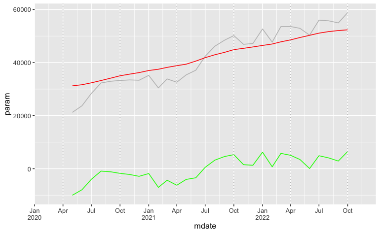

```r
plotlim <- as.Date(c("2020-01-01","2022-12-31"))
smoothed_data %>%
ggplot() +
  #geom_line(aes(x = mdate, y = c(param, moving_avg, mvar)))
  #above is an attempt to merge them - doesnt work!
  geom_line(aes(x = mdate, y = param), colour = "gray") +
  geom_line(aes(x = mdate, y = moving_avg), colour = "red") +
  geom_line(aes(x = mdate, y = mvar), colour = "green") +
  scale_x_date(limits=plotlim, date_breaks="3 month",
               labels = scales::label_date_short(), expand = c(0,0)) +
    # add dashed lines to show the boundaries
    geom_vline(xintercept=ymd(20201001),color="gray",linetype="dotted", linewidth = 0.5) +
    geom_vline(xintercept=ymd(20211001),color="gray",linetype="dotted", linewidth = 0.5) +
    geom_vline(xintercept=ymd(20221001),color="gray",linetype="dotted", linewidth = 0.5) +
    geom_vline(xintercept=ymd(20200401),color="gray",linetype="dotted", linewidth = 0.5) +
    geom_vline(xintercept=ymd(20210401),color="gray",linetype="dotted", linewidth = 0.5) +
    geom_vline(xintercept=ymd(20220401),color="gray",linetype="dotted", linewidth = 0.5)
```

#now create a boxplot this box plot will be added to the app

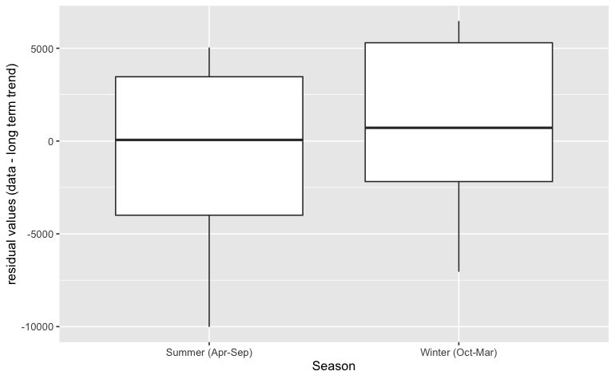

```r
smoothed_data %>%
  ggplot() +
  aes(x=iswinter, y=mvar) +
  geom_boxplot() +
  ylab("residual values (data - long term trend)") +
  xlab("Season") +
  scale_x_discrete(
    labels=c("FALSE" = "Summer (Apr-Sep)", "TRUE" = "Winter (Oct-Mar)"),
    limits = c("FALSE","TRUE"))
```

This box plot shows that for this dataset, the median values in summer were lower than the median values in winter, so there is a suggestion that there could be a seasonal variability here. However it is necessary to do a statistical test to determine if these differences are statistically significant.